# Customizing Charts Using ggplot2 extensions

Cyrus Wakibia

2023-09-24

*This document was last updated on 2023-09-28.*

### Some important themes

- `theme_minimal()`
- `ggthemes`
- `bbplots`
- `ggthemr`
- `The Economist`

## ggthemes: Improve your themes with this

# gghighlight: Highlight specific parts of the chart

# ggtext

Provides simple Markdown and HTML rendering for ggplot2

#### [reference](https://github.com/wilkelab/ggtext/)

### Key Functions

```
- element_markdown()
- element_textbox()
```

**`element_markdown()`**

- Both behave similarly to element_text() but render the provided text as markdown/html. `element_markdown()` is meant as a direct replacement for *`element_text()`*, and it renders text without word wrapping.
- To start a new line, use the **`<br>` tag or add two spaces** before the end of a line.

**`element_textbox()`**

- `element_textbox()` offers support for rendering larger amounts of text that require word wrapping.
- Unlike `element_markdown()`, it cannot be used for axis tick labels, and it cannot draw text at arbitrary angles, only at fixed orientations corresponding to 0, 90, 180, and 270 degrees.
- In practice, you will usually want to use *`element_textbox_simple()`* instead of *`element_textbox()`*, as it sets useful defaults for many parameters not usually defined in ggplot2 themes.

#### element_markdown()

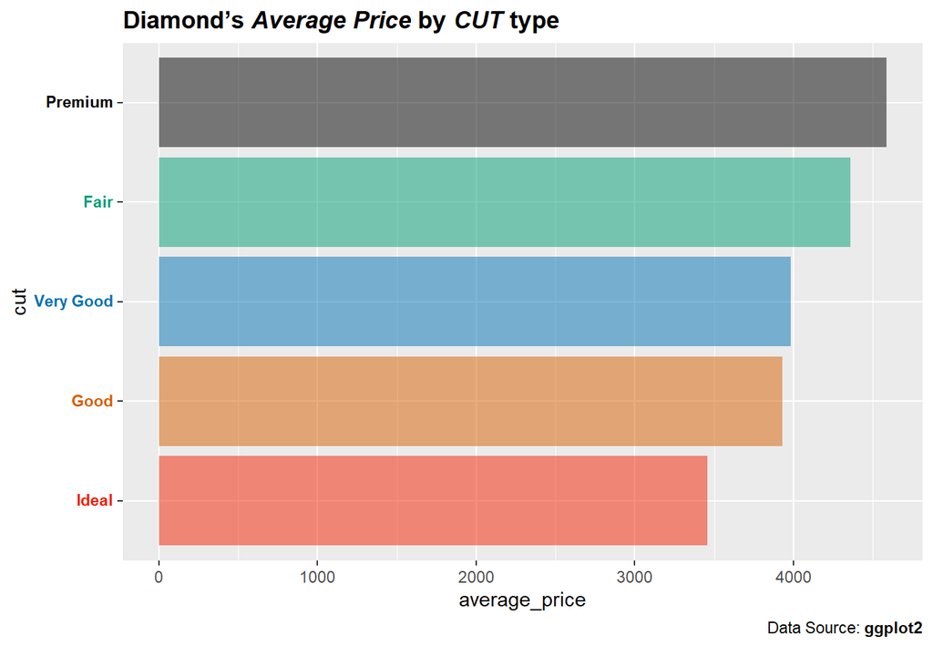

#### element_markdown()

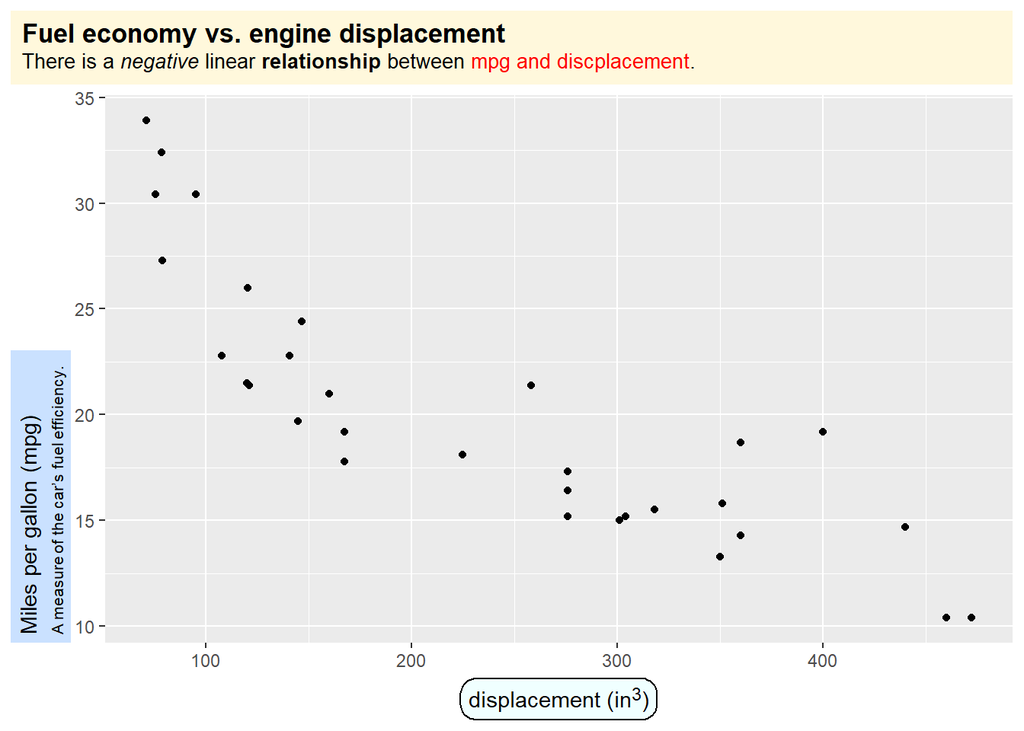

# ggrepel

Repel overlapping text labels away from each other.

It provides the following geoms: - geom_text_repel(): adds text directly to the plot - geom_label_repel(): draws a rectangle underneath the text, making it easier to read

```
**We can also disable clipping to allow the labels to go beyond the edges of the panel.**
```

**geom_text_repel**

*Text labels repel away from each other, away from data points, and away from edges of the plotting area (panel).*

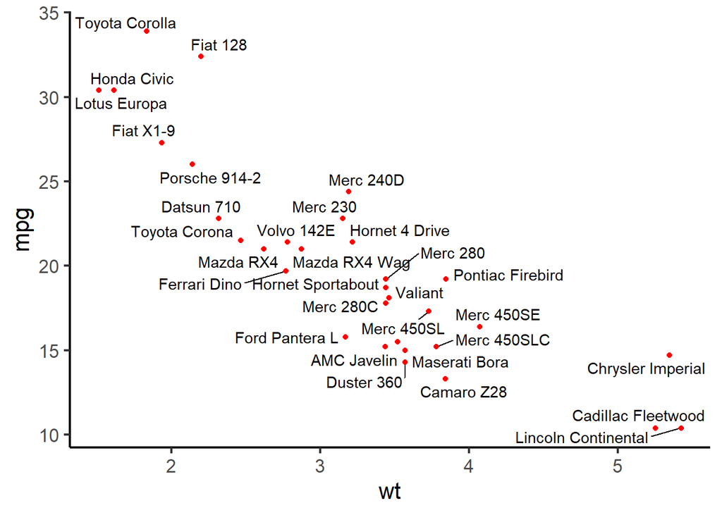

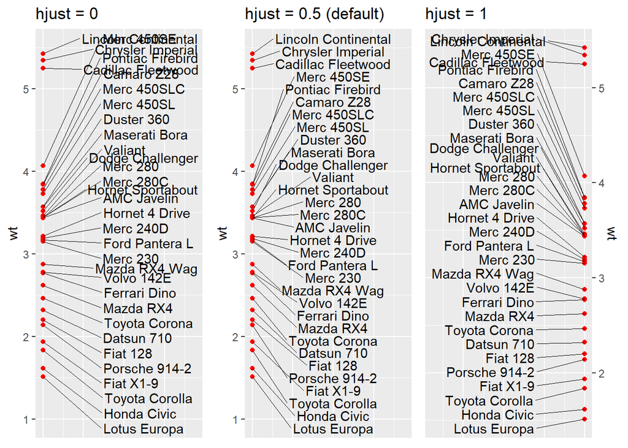

**geom_label_repel**

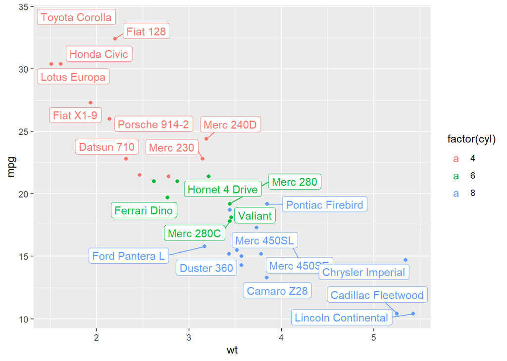

# ggforce

- The `ggforce` package is a ggplot2 extension that adds many exploratory data analysis features

  hull plots for visualizing clusters or groups within our data
- The Hull Plot is a visualization that produces a shaded areas around clusters (groups) within our data. It gets the name because of the Convex Hull shape. It’s a great way to show customer segments, group membership, and clusters on a Scatter Plot.

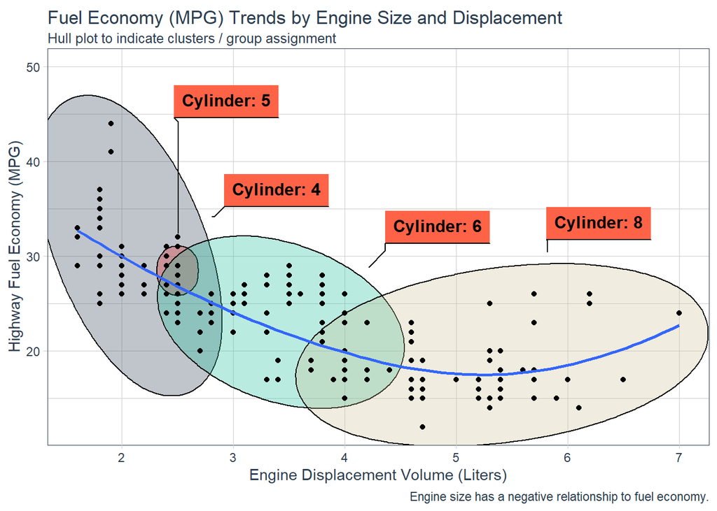

### ggplot2 recap

- `geom_path()` connects the observations in the order in which they appear in the data.
- `geom_line()` connects them in order of the variable on the x axis.
- `geom_step()` creates a stairstep plot, highlighting exactly when changes occur. The group aesthetic determines which cases are connected together.

#### `geom_line`

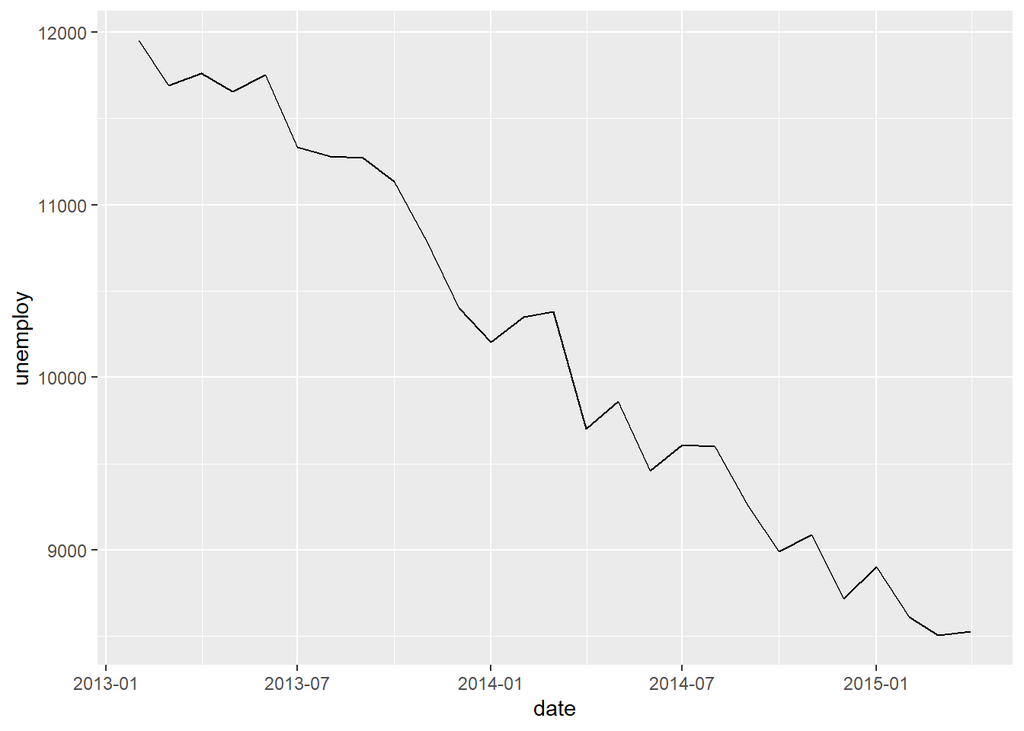

#### `geom_step`

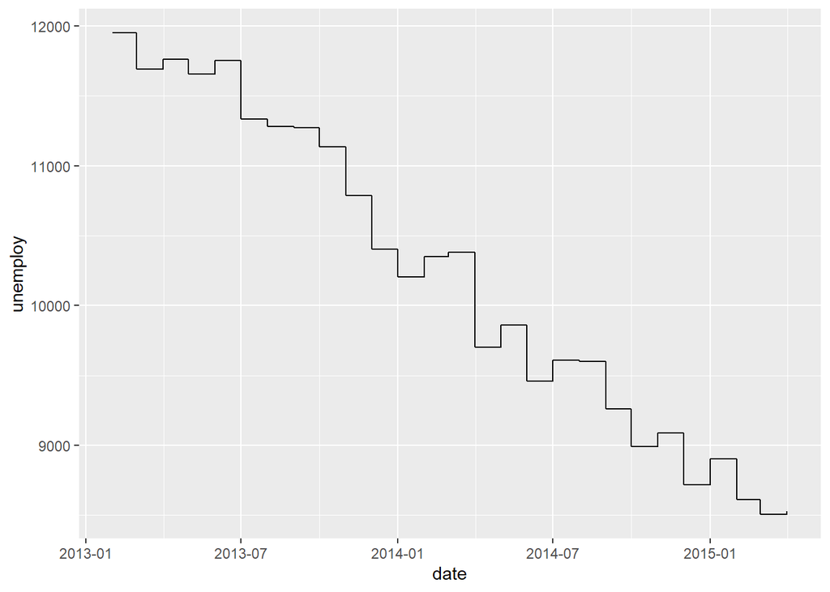

#### `geom_path`

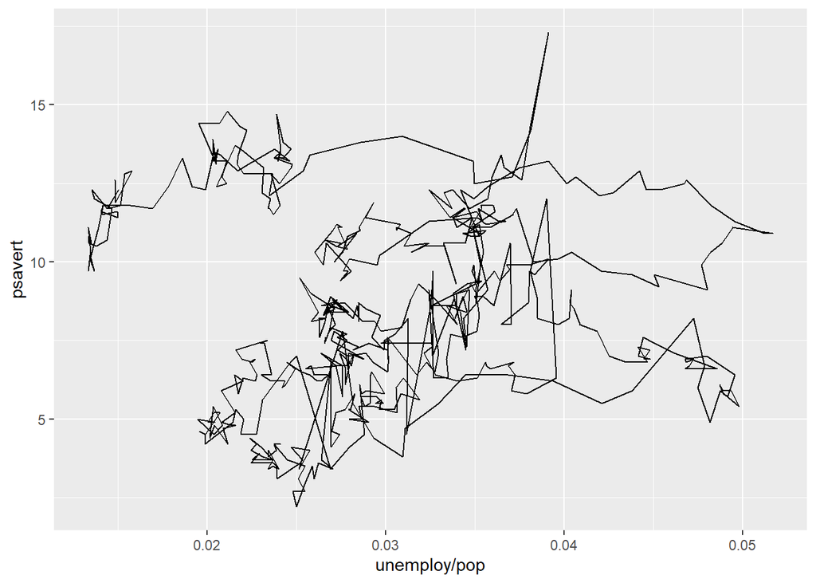

# geomtextpath

[reference](https://allancameron.github.io/geomtextpath/)

- The goal of the `geomtextpath` package is to directly label line-based plots with text that is able to follow a curved path
- Using `geomtextpath`, our text can follow any path, and will remain correctly spaced and angled, even if you change the size and aspect ratio of your plotting device.
- The core functions in this package(`geomtextpath`), `geom_textpath` and `geom_labelpath`, work like any other geom in ggplot2.
- They take their co-ordinates, their y co-ordinates and their text label from an aesthetic mapping.
  - The geoms for path, segment, *line, curve, density*, smooth, contour, sf; have two corresponding alternatiaves. e.g., textline and labelline. This follows for each of them

[figure not shown]

Add text in a textbox

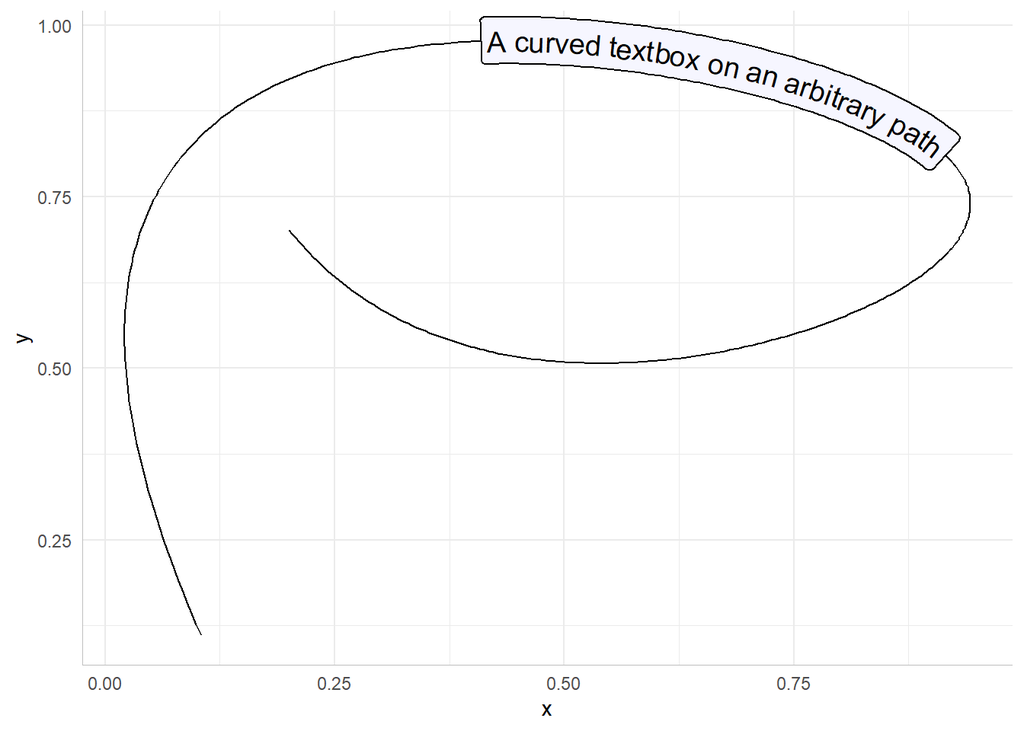

### **`geom_textline`** and **`geom_labelline`**

- You can use `geom_textline` and `geom_labelline` as a drop in for geom_line if you want it directly labelled. - Just pass the label you want as an argument to `geom_textline` (or if you have grouped data you can pass the label as an aesthetic mapping).

**Add text to the end of the line**

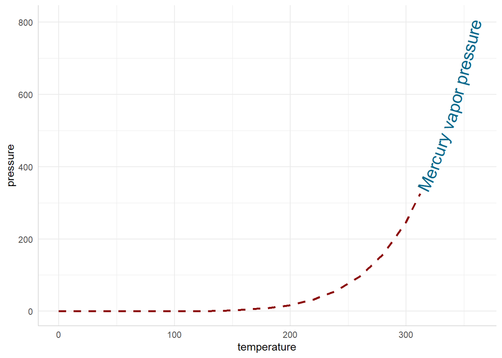

### Reference lines

- Often, a reference line added to a plot requires a text annotation.
- We can do this directly with `geom_textabline`, `geom_textvline` and `geom_texthline`, or their text-box equivalents `geom_labelabline`, `geom_labelvline` and `geom_labelhline.`
- Although such lines aren’t curved, there are some benefits to using the **`geomtextpath`** functions if a labelled reference line is required: only a single call is needed, co-ordinates are not required for the text label, the text can be put in-line with an appropriate break in the line automatically, and the label will orientate and curve appropriately in polar co-ordinates.

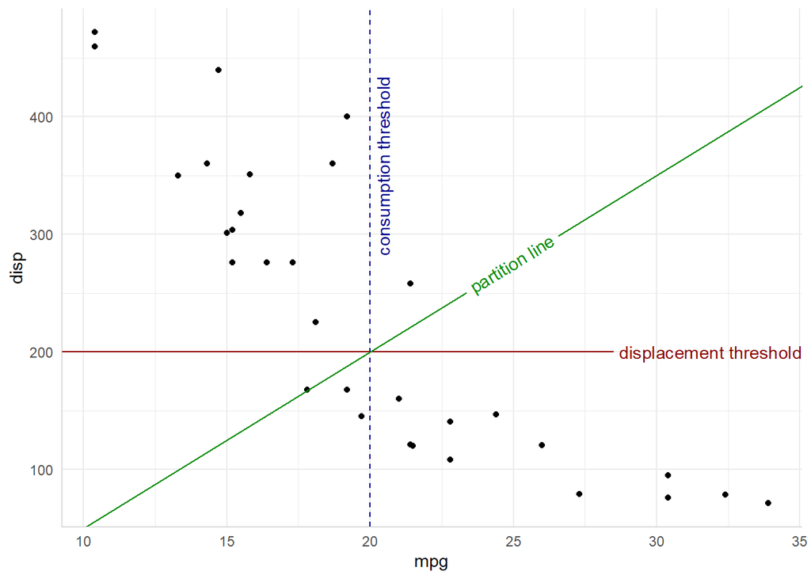